# Herramientas de programación para la producción y difusión de estadísticas socioeconómicas - ASET

Clase 4 - Visualizaciones en R

```r
library(tidyverse) # cargamos la librería tidyverse (que incorpora ggplot)
library(ggthemes) # diseños preconfigurados para los gráficos ggplot
library(readxl) # Cargamos readxl para traer levantar excels
```

### Gráficos Básicos en R

Rbase tiene algunos comandos genéricos para realizar gráficos, que se adaptan al tipo de información que se le pide graficar, por ejemplo:

- plot()
- hist()

```r
# iris es un set de datos clásico, que ya viene incorporado en R
iris[1:10,]
```

|  | Sepal.Length | Sepal.Width | Petal.Length | Petal.Width | Species |
| --- | --- | --- | --- | --- | --- |
| 1 | 5.1 | 3.5 | 1.4 | 0.2 | setosa |
| 2 | 4.9 | 3.0 | 1.4 | 0.2 | setosa |
| 3 | 4.7 | 3.2 | 1.3 | 0.2 | setosa |
| 4 | 4.6 | 3.1 | 1.5 | 0.2 | setosa |
| 5 | 5.0 | 3.6 | 1.4 | 0.2 | setosa |
| 6 | 5.4 | 3.9 | 1.7 | 0.4 | setosa |
| 7 | 4.6 | 3.4 | 1.4 | 0.3 | setosa |
| 8 | 5.0 | 3.4 | 1.5 | 0.2 | setosa |
| 9 | 4.4 | 2.9 | 1.4 | 0.2 | setosa |
| 10 | 4.9 | 3.1 | 1.5 | 0.1 | setosa |

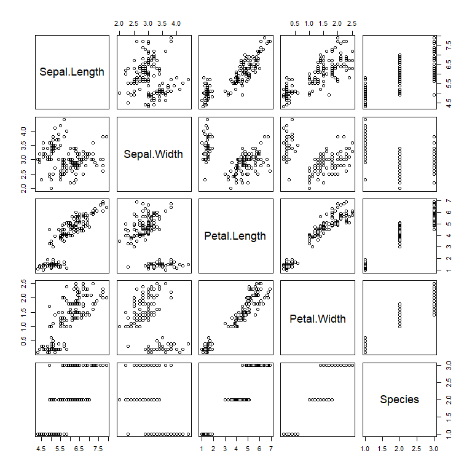

```r
plot(iris)
```

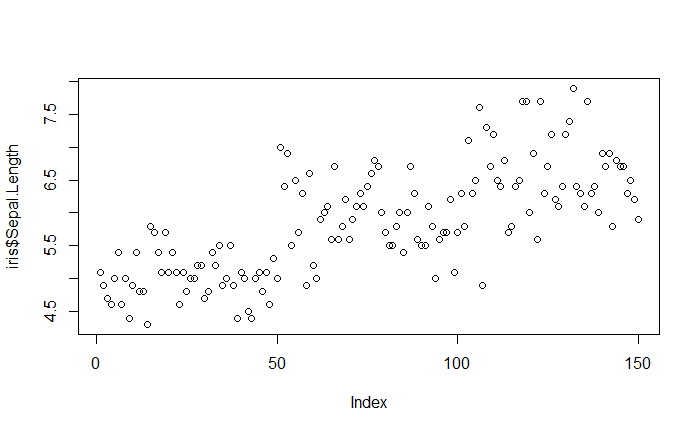

```r
#Al especificar una variable, puedo ver el valor que toma cada uno de sus registros (Index)
plot(iris$Sepal.Length,type = "p") # Un punto por cada valor
```

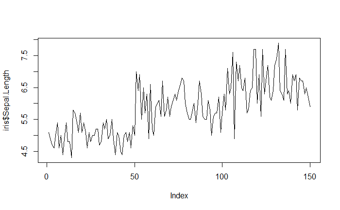

```r
plot(iris$Sepal.Length,type = "l") # Una linea que una cada valor
```

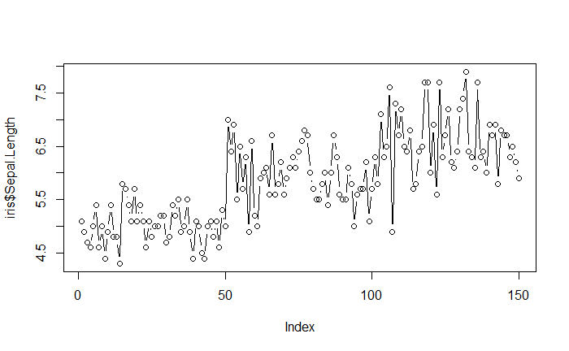

```r
plot(iris$Sepal.Length,type = "b") #Ambas
```

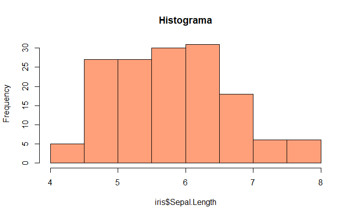

```r
hist(iris$Sepal.Length, col = "lightsalmon1", main = "Histograma")
```

#### png

La función `png()` nos permite grabar una imagen en el disco. Lleva como argumento principal la ruta completa a donde se desea guardar la misma, incluyendo el nombre que queremos dar al archivo. A su vez pueden especificarse otros argumentos como el ancho y largo de la imagen, entre otros.

```r
ruta_archivo <- "../grafico1.PNG"
ruta_archivo
png(ruta_archivo)
plot(iris$Sepal.Length,type = "b")
dev.off()
```

La función `png()` *abre el dispositivo de imagen* en el directorio especificado. Luego creamos el gráfico que deseamos (o llamamos a uno previamente construido), el cual se desplegará en la ventana inferior derecha de la pantalla de Rstudio. Finalmente con `dev.off()` se *cierra el dispositivo* y se graban los gráficos.

Los gráficos del R base son útiles para escribir de forma rápida y obtener alguna información mientras trabajamos. Muchos paquetes estadísticos permiten mostrar los resultados de forma gráfica con el comando `plot` (por ejemplo, las regresiones lineales `lm()`).

Sin embargo, existen librerías mucho mejores para crear gráficos de nivel de publicación. La más importante es **ggplot2**, que a su vez tiene extensiones mediante otras librerías.

### [Ggplot2](http://ggplot2.tidyverse.org/reference/)

`ggplot` tiene su sintaxis propia. La idea central es pensar los gráficos como una sucesión de capas, que se construyen una a la vez.

- El operador **`+`** nos permite incorporar nuevas capas al gráfico.
- El comando `ggplot()` nos permite definir la fuente de **datos** y las **variables** que determinaran los ejes del grafico (x,y), así como el color y la forma de las líneas o puntos,etc.
- Las sucesivas capas nos permiten definir:
  - Uno o más tipos de gráficos (de columnas, `geom_col()`, de línea, `geom_line()`, de puntos, `geom_point()`, boxplot, `geom_boxplot()`)
  - Títulos `labs()`
  - Estilo del gráfico `theme()`
  - Escalas de los ejes `scale_y_continuous`,`scale_x_discrete`
  - División en subconjuntos `facet_wrap()`,`facet_grid()`

`ggplot` tiene **muchos** comandos, y no tiene sentido saberlos de memoria, es siempre útil reutilizar gráficos viejos y tener a mano el [machete](https://www.rstudio.com/wp-content/uploads/2016/11/ggplot2-cheatsheet-2.1.pdf).

#### Dimensiones del gráfico

Esta forma de pensar los gráficos nos permite repenser los distintos atributos como potenciales aliados a la hora de mostrar información multidimensional. Por ejemplo:

- [**color**](http://www.stat.columbia.edu/~tzheng/files/Rcolor.pdf) `color =`
- **relleno**`fill =`
- **forma** `shape =`
- **tamaño** `size =`
- **transparencia** `alpha =`
- Abrir un mismo gráfico según alguna variable discreta: `facet_wrap()`
- Los atributos que queremos que *mapeen* una variable, deben ir **dentro del aes()**, `aes(... color = variable)`
- Cuando queremos simplemente mejorar el diseño (es fijo), se asigna por fuera, o dentro de cada tipo de gráficos, `geom_col(color = 'green')`.

##### Gráfico de Puntos

A continuación vamos a crear un **dataframe** como insumo para realizar un gráfico de puntos. Visualizaremos el salario promedio y la tasa de no registro, para cada uno de los aglomerados EPH. El tamaño de los puntos estará seteado en función de la cantidad de asalariados, y el color en función de la región de pertenencia

- Cargamos una base de la EPH, y los diccionarios de regiones y aglomerados.
- Agrupamos por aglomerado (y región) y estimamos la tasa de no registro y el salario promedio

```r
Individual_t119 <- eph::get_microdata(year = 2019,period = 1)

aglomerados <- read_excel("Fuentes/Aglomerados EPH.xlsx")
regiones <- read_excel("Fuentes/Regiones.xlsx")

salario_y_no_registro <- Individual_t119 %>%
  filter(ESTADO == 1, CAT_OCUP == 3) %>%
  group_by(ANO4,TRIMESTRE,REGION,AGLOMERADO) %>%
  summarise(tasa_no_reg = sum(PONDERA[PP07H == 2])/sum(PONDERA),
            salario_prom = weighted.mean(P21,PONDIIO),
            asalariados = sum(PONDERA)) %>%
  ungroup() %>%
  left_join(aglomerados,by = c("AGLOMERADO")) %>%
  left_join(regiones,by = c("REGION"))

salario_y_no_registro
```

| ANO4 | TRIMESTRE | REGION | AGLOMERADO | tasa_no_reg | salario_prom | asalariados | Nom_Aglo | Region |
| --- | --- | --- | --- | --- | --- | --- | --- | --- |
| 2019 | 1 | 1 | 32 | 0.2309586 | 26999.58 | 1160013 | Ciudad de Bs As | GBA |
| 2019 | 1 | 1 | 33 | 0.3774556 | 19228.47 | 3818836 | Partidos del GBA | GBA |
| 2019 | 1 | 40 | 18 | 0.4487665 | 13464.00 | 114759 | S.del Estero - La Banda | Noroeste |
| 2019 | 1 | 40 | 19 | 0.3448909 | 16849.31 | 104549 | Jujuy - Palpalá | Noroeste |
| 2019 | 1 | 40 | 22 | 0.3479583 | 16449.47 | 71043 | Gran Catamarca | Noroeste |
| 2019 | 1 | 40 | 23 | 0.4440784 | 15899.70 | 168459 | Salta | Noroeste |
| 2019 | 1 | 40 | 25 | 0.3552461 | 15529.34 | 74979 | La Rioja | Noroeste |
| 2019 | 1 | 40 | 29 | 0.4899420 | 15748.88 | 266454 | Gran Tucumán - T. Viejo | Noroeste |
| 2019 | 1 | 41 | 7 | 0.3345450 | 18175.61 | 109492 | Posadas | Noreste |
| 2019 | 1 | 41 | 8 | 0.4092893 | 15603.14 | 115251 | Gran Resistencia | Noreste |

[output cut: 22 more lines]

#### Aquí se muestra el gráfico final a alcanzar.

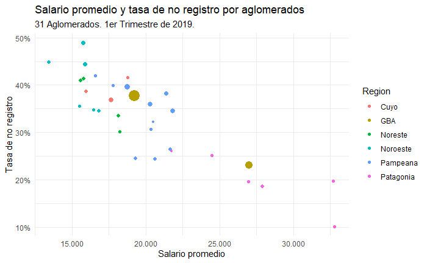

**Capas del Gráfico**

Veamos ahora, el “paso a paso” o “capa a capa” del gráfico. Dentro de `ggplot()`:

- Defino el dataframe que voy a utilizar con el parámetro `data =`
- Defino los parametros estéticos del gráfico que van a depender de las variables de mi dataframe dentro del `aes()`

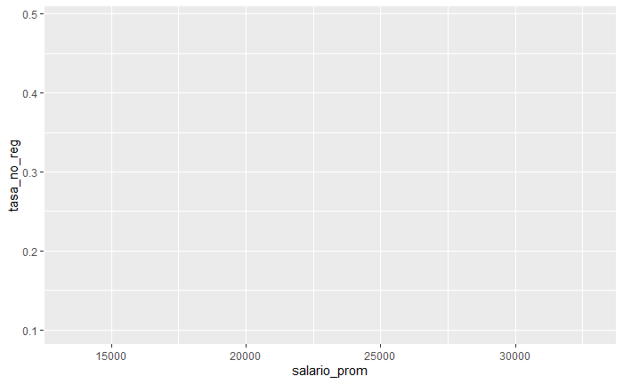

```r
capa1 <- ggplot(data = salario_y_no_registro,
                aes(x = salario_prom,
                y = tasa_no_reg,
                size = asalariados,
                color = Region))

capa1
```

- Defino el tipo de geometría de gráfico que quiero (en este caso de puntos, pero podría ser de columnas, líneas, densidad, etc)

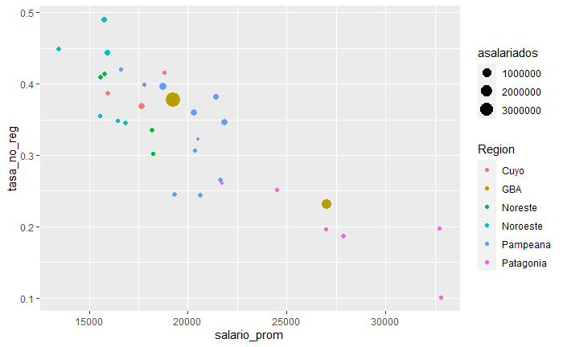

```r
capa2 <- capa1 +
  geom_point()

capa2
```

- Con la capa labs() puedo definir título, subtitulo y nombres de ejes del gráfico

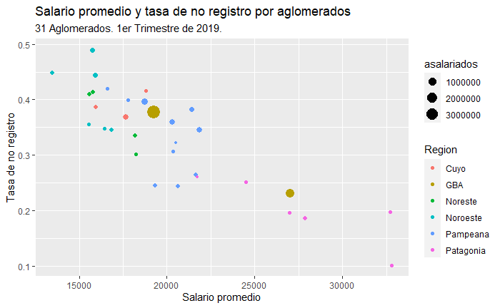

```r
capa3 <- capa2 +
  labs(title = "Salario promedio y tasa de no registro por aglomerados",
       subtitle = "31 Aglomerados. 1er Trimestre de 2019.",
       x = "Salario promedio",
       y = "Tasa de no registro")

capa3
```

- En la capa de `theme()` puedo cambiar el diseño del cuadrante donde se visualizan los datos. En este caso usé la función `theme_minimal()`del paquete **ggthemes** que tiene definido un tema con fondo blanco y pequeñas líneas grises para seguir la línea de los números que se muestran en el eje.
- En la capa de `guides()` es donde puedo modificar todo lo vinculado a las leyendas del gráfico. En este caso, lo usamos para eliminar la leyenda asociada al tamaño de los puntos. También allí podría modificar el título de la otra leyenda, el tamaño de los puntos, etc.
- Las últimas dos capas `scale_y_continuous()` y `scale_x_continuous()` me permiten modificar las escalas de los respectivos ejes, cambiar el formato en el que aparecen los números, o cuántas referencias mostrar de la escala en cuestión.

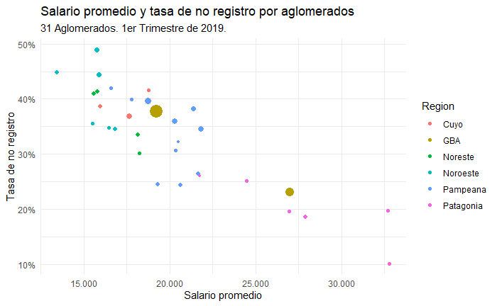

```r
grafico_final <- capa3 +
theme_minimal()+
  guides(size = FALSE)+
  scale_y_continuous(labels = scales::percent_format(accuracy = 1))+
  scale_x_continuous(labels = scales::number_format(big.mark = ".",decimal.mark = ","))


grafico_final
```

### Extensiones de [GGplot](https://exts.ggplot2.tidyverse.org/gallery/).

La librería GGplot tiene a su vez muchas otras librerías que extienden sus potencialidades. Entre nuestras favoritas están:

- [ggplotly](https://plotly.com/ggplot2/): Para hacer gráficos interactivos
- [gganimate](https://gganimate.com/): Para hacer gráficos animados.
- [ggridge](https://cran.r-project.org/web/packages/ggridges/vignettes/introduction.html): Para hacer gráficos de densidad faceteados
- [ggally](https://ggobi.github.io/ggally/): Para hacer varios gráficos juntos.
- [treemapify](https://cran.r-project.org/web/packages/treemapify/vignettes/introduction-to-treemapify.html)

#### Plotly

Con la librería plotly podemos rápidamente hacer interactivo un gráfico de ggplot. Simplemente tenemos que aplicar al función `ggplotly()` a nuestro gráfico.

En el parámetro `tooltip =` le podemos pasar que variable queremos que se muestre al pasar por la geometría del gráfico con el mouse.

```r
library(plotly)

grafico_final <- ggplot(data = salario_y_no_registro,
       aes(x = salario_prom,
       y = tasa_no_reg,
       size = asalariados,
       aglo = Nom_Aglo, #Aca creo un parametro del aes que depende de Nom_Aglo
       color = Region))+
  geom_point()+
  labs(title = "Salario promedio y tasa de no registro por aglomerados",
       subtitle = "31 Aglomerados. 1er Trimestre de 2019.",
       x = "Salario promedio",
       y = "Tasa de no registro")+
  theme_minimal()+
  guides(size = F)+
  scale_y_continuous(labels = scales::percent_format(accuracy = 1))+
  scale_x_continuous(labels = scales::number_format(big.mark = ".",decimal.mark = ","))
```

```r
ggplotly(grafico_final,tooltip = "aglo") # Ver en vivo
```

#### GGally

Permite visualizar rápidamente el cruce de todas las variables de un dataframe

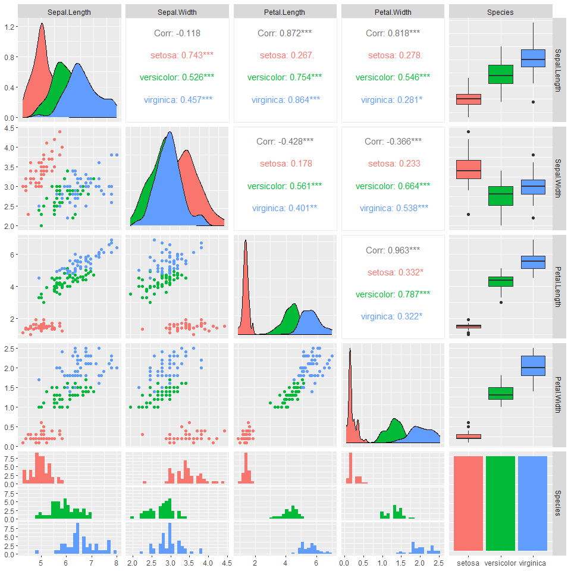

```r
library(GGally)

ggpairs(iris,  mapping = aes(color = Species))
```

- Creamos acá un nuevo dataframe para mostrar otros gráficos
  - sólo con los casos de ingreso de la ocupación principal mayores a 0.
  - Con una variable categórica para el sexo

```r
base_para_otros_ejemplos <- Individual_t119 %>%
  left_join(regiones) %>%
  filter(P21>0) %>%
  mutate(Sexo = case_when(CH04 == 1 ~ "Varón",
                          CH04 == 2 ~ "Mujer"))
```

#### ggridges

Util para comparar distribuciones según distintas categorías

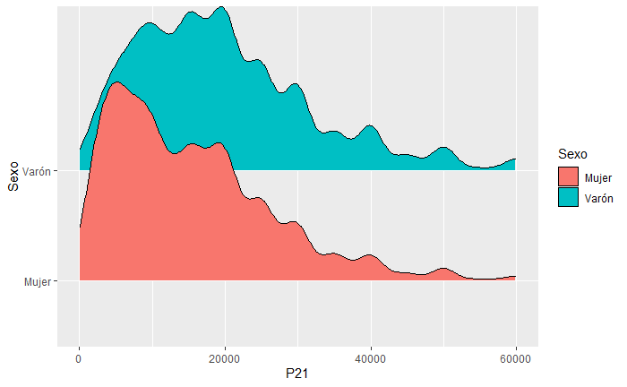

```r
library(ggridges)

ggplot(base_para_otros_ejemplos, aes(x = P21, y = Sexo, fill=Sexo)) +
  geom_density_ridges()+
  scale_x_continuous(limits = c(0,60000))#Restrinjo el gráfico hasta ingresos de $60000
```

#### esquisse

También hay extensiones que te ayudan a escribir el código, como [esquisse](https://dreamrs.github.io/esquisse/)

```r
iris <- iris
#Correr en la consola
esquisse::esquisser()
```

### Otros ejemplos

#### Boxplot de ingresos de la ocupación principal, según región

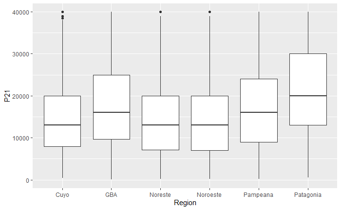

```r
ggplot(base_para_otros_ejemplos, aes(x = Region, y = P21)) +
  geom_boxplot()+
  scale_y_continuous(limits = c(0, 40000))#Restrinjo el gráfico hasta ingresos de $40000
```

Si queremos agregar la dimensión *sexo*, podemos hacer un `facet_wrap()`

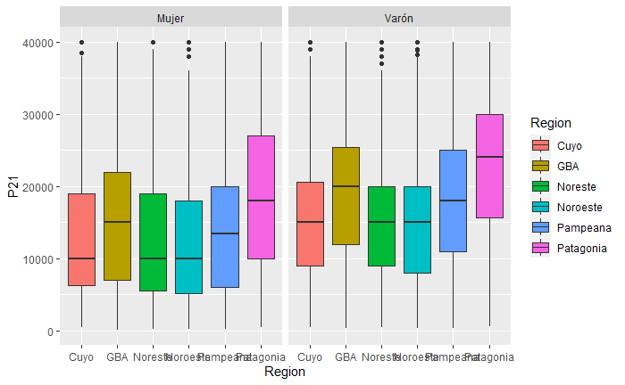

```r
ggplot(base_para_otros_ejemplos, aes(x= Region, y = P21 ,fill = Region )) +
  geom_boxplot()+
  scale_y_continuous(limits = c(0, 40000))+
  facet_wrap(vars(Sexo))
```

Por la forma en que está presentado el gráfico, el foco de atención sigue puesto en las diferencias de ingresos entre regiones. Simplemente se agrega un corte por la variable de sexo.

Si lo que queremos hacer es poner el foco de atención en las diferencias por sexo, simplemente basta con invertir la variable x especificada con la variable utilizada en el `facet_wrap`

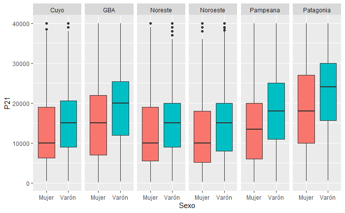

```r
ggplot(base_para_otros_ejemplos, aes(x= Sexo, y = P21, group = Sexo, fill = Sexo )) +
  geom_boxplot()+
  scale_y_continuous(limits = c(0, 40000))+
  facet_wrap(vars(Region),nrow = 1) +
  theme(legend.position = "none")
```

#### [Histogramas](https://ggplot2.tidyverse.org/reference/geom_histogram.html)

Por ejemplo, si observamos el ingreso de la ocupación principal:

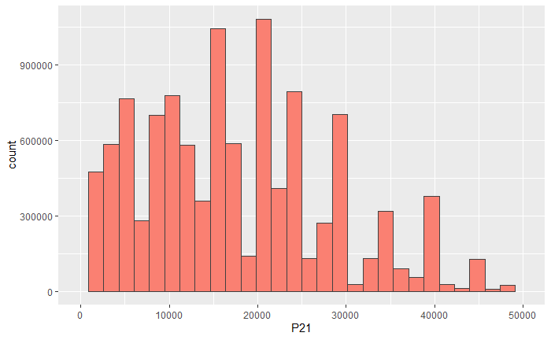

```r
ggplot(base_para_otros_ejemplos, aes(x = P21,weights = PONDIIO))+
geom_histogram(fill='salmon', color='grey25')+
scale_x_continuous(limits = c(0,50000))
```

En este gráfico, los posibles valores de p21 se dividen en 30 **bins** consecutivos y el gráfico muestra cuantas observaciones caen en cada uno de ellos

#### [Kernels](https://plot.ly/ggplot2/geom_density/)

La función `geom_density()` nos permite construir **kernels** de la distribución. Es particularmente útil cuando tenemos una variable continua, dado que los histogramas rompen esa sensación de continuidad.

Veamos un ejemplo sencillo con los ingresos de la ocupación principal. Luego iremos complejizandolo

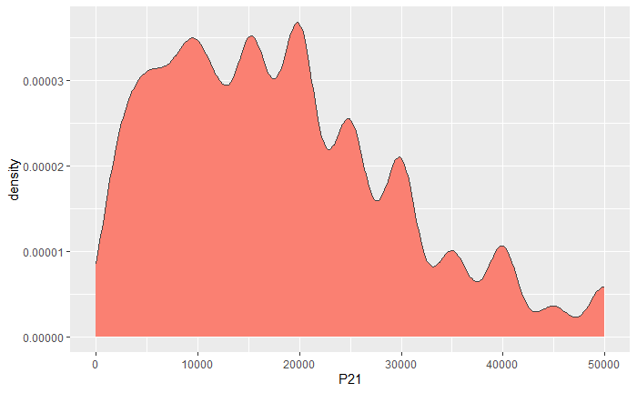

```r
ggplot(base_para_otros_ejemplos, aes(x = P21,weights = PONDIIO))+
geom_density(fill='salmon', color='grey25')+
scale_x_continuous(limits = c(0,50000))
```

**El eje y no tiene demasiada interpretabilidad en los Kernel, porque hace a la forma en que se construyen las distribuciones**.

El parametro adjust, dentro de la función `geom_density`nos permite reducir o ampliar el rango de suavizado de la distribución. Su valor por default es 1. Veamos que sucede si lo seteamos en 2

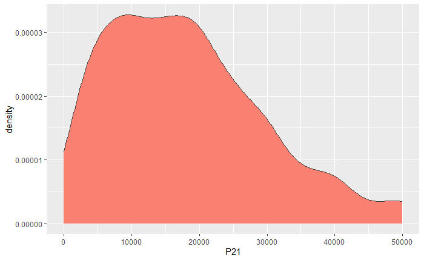

```r
ggplot(base_para_otros_ejemplos, aes(x = P21,weights = PONDIIO))+
geom_density(adjust = 2,fill='salmon', color='grey25')+
scale_x_continuous(limits = c(0,50000))
```

Como es esperable, la distribución del ingreso tiene “picos” en los valores redondos, ya que la gente suele declarar un valor aproximado al ingreso efectivo que percibe. Nadie declara ingresos de 30001. Al suavizar la serie con un kernel, eliminamos ese efecto.Si seteamos el rango para el suavizado en valores menores a 1, podemos observar estos picos.

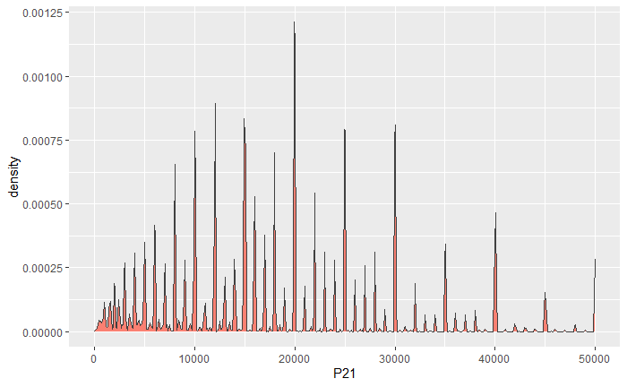

```r
ggplot(base_para_otros_ejemplos, aes(x = P21,weights = PONDIIO))+
geom_density(adjust = 0.01,fill='salmon', color='grey25')+
scale_x_continuous(limits = c(0,50000))
```

#### Geom Smooth

Para realizar estos gráficos, vamos a modificar un poco los datos:

- filtramos los ingresos iguales a 0.
- eliminamos las no respuestas de nivel educativo y las personas con educación especial.
- eliminamos las respuestas de tipo de establecimiento = ‘otros’.
- recodificamos las variables para que tengan nombres más sugestivos:
  - **Nivel educativo** además la convertimos a factor, porque queremos explicitarle el orden de los valores con `levels()`. El “\n”” es un *caracter especial* que permite que el string continúe en la siguiente línea.
  - Sexo.
  - Tipo de establecimiento.

```r
ggdata <- base_para_otros_ejemplos %>%
  filter(!is.na(NIVEL_ED),
         NIVEL_ED!=7,
         PP04A !=3) %>%
  mutate(NIVEL_ED = factor(case_when(NIVEL_ED == 1  ~ 'Primaria \n Incompleta', # '\n' significa carriage return, o enter
                                     NIVEL_ED == 2  ~ 'Primaria \n Completa',
                                     NIVEL_ED == 3  ~ 'Secundaria \nIncompleta',
                                     NIVEL_ED == 4  ~ 'Secundaria \nCompleta',
                                     NIVEL_ED == 5  ~ 'Superior \nUniversitaria \nIncompleta',
                                     NIVEL_ED == 6  ~ 'Superior \nUniversitaria \nCompleta',
                                     FALSE          ~ 'Otro'),
                           levels= c('Primaria \n Incompleta',
                                     'Primaria \n Completa',
                                     'Secundaria \nIncompleta',
                                     'Secundaria \nCompleta',
                                     'Superior \nUniversitaria \nIncompleta',
                                     'Superior \nUniversitaria \nCompleta')),
         Sexo     = case_when(CH04 == 1 ~ 'Varón',
                              CH04 == 2 ~ 'Mujer'),
         Establecimiento    = case_when(PP04A == 1 ~ 'Estatal',
                                        PP04A == 2 ~ 'Privado',
                                        FALSE      ~ 'Otro'))

ggdata
```

| CODUSU | ANO4 | TRIMESTRE | NRO_HOGAR | COMPONENTE | H15 | REGION | MAS_500 | AGLOMERADO | PONDERA | CH03 | CH04 | CH05 | CH06 | CH07 | CH08 | CH09 | CH10 | CH11 | CH12 | CH13 | CH14 | CH15 | CH15_COD | CH16 | CH16_COD | NIVEL_ED | ESTADO | CAT_OCUP | CAT_INAC | … |
| --- | --- | --- | --- | --- | --- | --- | --- | --- | --- | --- | --- | --- | --- | --- | --- | --- | --- | --- | --- | --- | --- | --- | --- | --- | --- | --- | --- | --- | --- | --- |
| TQRMNORUQHKNKNCDEFOCD00629563 | 2019 | 1 | 1 | 1 | 1 | 41 | N | 8 | 108 | 1 | 2 | 30/03/1978 | 41 | 5 | 4 | 1 | 2 | 0 | 6 | 2 | 3 | 1 | NA | 1 | NA | Superior \nUniversitaria \nIncompleta | 1 | 3 | 0 | … |
| TQRMNOPUVHKOKMCDEFOCD00629564 | 2019 | 1 | 1 | 2 | 1 | 41 | N | 8 | 141 | 1 | 1 | 26/04/1967 | 51 | 3 | 4 | 1 | 2 | 0 | 2 | 2 | 4 | 1 | NA | 1 | NA | Primaria \n Incompleta | 1 | 2 | 0 | … |
| TQRMNOQWXHMNLPCDEFOCD00629566 | 2019 | 1 | 1 | 1 | 1 | 41 | N | 8 | 221 | 1 | 1 | 22/07/1944 | 74 | 4 | 1 | 1 | 2 | 0 | 2 | 2 | 4 | 2 | NA | 1 | NA | Primaria \n Incompleta | 1 | 3 | 0 | … |
| TQRMNORPQHMMLQCDEFOCD00629567 | 2019 | 1 | 1 | 1 | 1 | 41 | N | 8 | 309 | 1 | 1 | 14/06/1976 | 42 | 2 | 4 | 1 | 2 | 0 | 4 | 1 | NA | 1 | NA | 1 | NA | Secundaria \nCompleta | 1 | 2 | 0 | … |
| TQRMNOPPYHMMLQCDEFOCD00629568 | 2019 | 1 | 1 | 1 | 1 | 41 | N | 8 | 309 | 1 | 2 | 02/01/1967 | 52 | 3 | 1 | 1 | 2 | 0 | 8 | 1 | NA | 1 | NA | 1 | NA | Superior \nUniversitaria \nCompleta | 1 | 3 | 0 | … |
| TQRMNOPRXHKMKPCDEFOCD00629569 | 2019 | 1 | 1 | 1 | 1 | 41 | N | 8 | 88 | 1 | 1 | 15/08/1974 | 44 | 2 | 1 | 1 | 2 | 0 | 7 | 1 | NA | 1 | NA | 1 | NA | Superior \nUniversitaria \nCompleta | 1 | 3 | 0 | … |
| TQRMNOTSPHJOLPCDEFOCD00629601 | 2019 | 1 | 1 | 1 | 1 | 41 | N | 8 | 577 | 1 | 1 | 25/11/1989 | 29 | 5 | 4 | 1 | 2 | 0 | 4 | 1 | NA | 1 | NA | 1 | NA | Secundaria \nCompleta | 1 | 3 | 0 | … |
| TQRMNOSQQHLKKMCDEFOCD00601459 | 2019 | 1 | 1 | 1 | 1 | 41 | N | 8 | 332 | 1 | 2 | 24/08/1980 | 38 | 5 | 1 | 1 | 2 | 0 | 4 | 1 | NA | 1 | NA | 1 | NA | Secundaria \nCompleta | 1 | 3 | 0 | … |
| TQRMNORUQHLOLQCDEFOCD00601495 | 2019 | 1 | 1 | 1 | 1 | 41 | N | 8 | 183 | 1 | 2 | 11/10/1957 | 61 | 3 | 4 | 1 | 2 | 0 | 2 | 2 | 2 | 2 | NA | 1 | NA | Primaria \n Incompleta | 1 | 3 | 0 | … |
| TQRMNORUQHLOLQCDEFOCD00601495 | 2019 | 1 | 1 | 2 | 1 | 41 | N | 8 | 183 | 3 | 1 | 23/12/1993 | 25 | 5 | 4 | 1 | 2 | 0 | 4 | 2 | 4 | 1 | NA | 1 | NA | Secundaria \nIncompleta | 1 | 3 | 0 | … |

[output cut: 990 more lines]

Para graficar un suavizado de las series, se utiliza la función [`geom_smooth()`](http://ggplot2.tidyverse.org/reference/geom_smooth.html). Con suavizado nos referimos al gráfico de un modelo realizado sobre los datos, que estima el valor en el punto x,y (para el grupo). Las regresiones lineales son un ejemplo de esto, aunque no el único, ni el que viene por default.

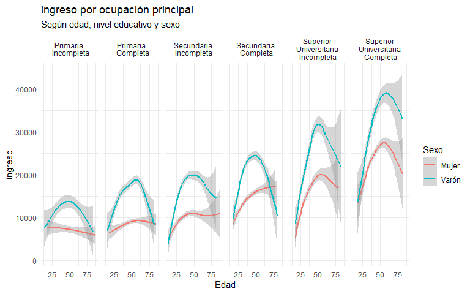

```r
ggplot(ggdata, aes(CH06, P21, colour = Sexo, shape = Sexo, alpha = P21))+
  geom_smooth() +
  labs(
    x = 'Edad',
    y = 'ingreso',
    title = 'Ingreso por ocupación principal',
    subtitle = 'Según edad, nivel educativo y sexo') +
  theme_minimal()+
  scale_y_continuous()+
  scale_alpha(guide = FALSE)+
  facet_grid(~NIVEL_ED)
```

Si corremos el comando `geom_smooth()` por default, nos advierte que esta utilizando el método GAM, de [general additive models](https://m-clark.github.io/generalized-additive-models/building_gam.html).

el **sombreado gris** que envuelve cada línea es el intervalo de confianza de dicho punto (95% por default).

También podemos utilizar métodos lineales, agregando el parámetro `method = 'lm'`. Haciendo esto, el gráfico muestra una regresión lineal simple. Si queremos otro tipo de regresión lineal, le podemos explicitar la fórmula.  
En el ejemplo siguiente, utilizamos la formula $y = \beta_0 +\beta_1x +\beta_2 x^2$.

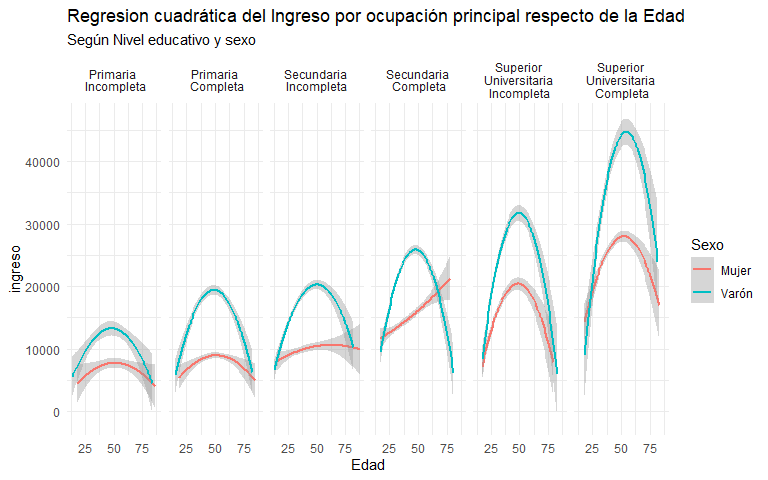

```r
ggplot(ggdata, aes(CH06, P21, colour = Sexo, weight = PONDIIO)) +
  geom_smooth(method = "lm", formula = y ~ poly(x, 2)) +
  labs(x = 'Edad',
       y = 'ingreso',
       title = 'Regresion cuadrática del Ingreso por ocupación principal respecto de la Edad',
       subtitle = 'Según Nivel educativo y sexo') +
  theme_minimal()+
  facet_grid( ~ NIVEL_ED)
```

Si quisiéramos, además de ver la relación entre ingreso, Edad, Sexo y Nivel educativo, incorporar el tipo de establecimiento,público o privado. Podemos facetear el gráfico por dos variables en lugar de una, lo que crea una **matriz de gráficos** según los cruces.

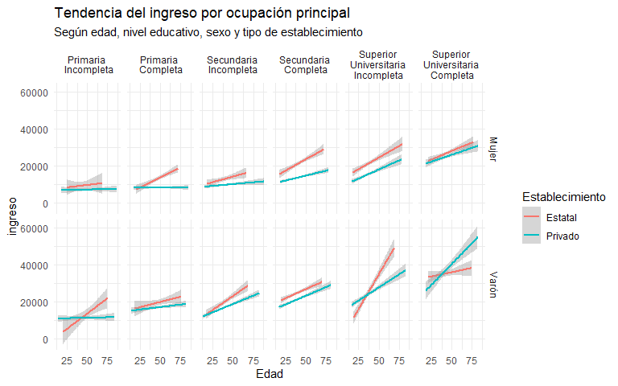

```r
ggplot(ggdata, aes(CH06, P21, colour = Establecimiento, weight = PONDIIO)) +
  geom_smooth(method = "lm") +
  labs(
  x = 'Edad',
  y = 'ingreso',
  title = 'Tendencia del ingreso por ocupación principal',
  subtitle = 'Según edad, nivel educativo, sexo y tipo de establecimiento') +
  theme_minimal()+
  facet_grid(Sexo ~ NIVEL_ED)
```

```r
#ggsave(filename = paste0("../regresion lineal.png"),scale = 2)
```